# FABIA Biclustering Analysis

Author

Tim

Published

April 9, 2026

# Vanilla LEMUR

We simply perform the baseline LEMUR analysis workflow on the shipped test data set.

```r
devtools::load_all("/Users/herbermann/code/lemur_biclusters/lemur")
library("lemur")
library("tidyverse")
library("SingleCellExperiment")
library("patchwork")

set.seed(42)

data("glioblastoma_example_data", package = "lemur")
glioblastoma_example_data
```

```r
fit <- lemur(glioblastoma_example_data, design = ~ patient_id + condition,
             n_embedding = 15, test_fraction = 0.5)

fit <- align_harmony(fit)


fit <- compute_contrasts(fit, contrast = cond(condition = "panobinostat") - cond(condition = "ctrl"))

neighborhoods <- find_de_neighborhoods(fit, group_by = vars(patient_id, condition))
```

Compute a simple reference UMAP and show one gene for reference purposes only.

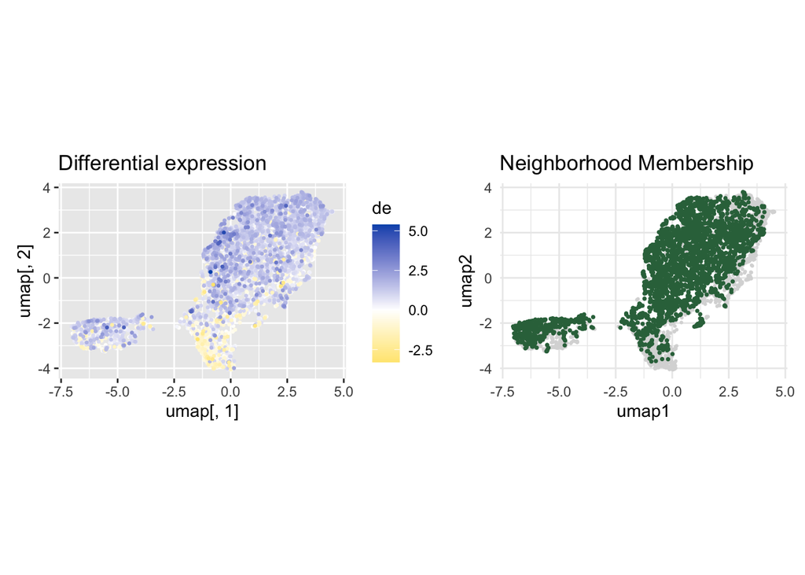

```r
umap <- uwot::umap(t(fit$embedding))

sel_gene <- "ENSG00000169429" # is CXCL8

p_de <- tibble(umap = umap) |>
  mutate(de = assay(fit, "DE")[sel_gene,]) |>
  arrange(abs(de)) |>
  ggplot(aes(x = umap[,1], y = umap[,2])) +
    geom_point(aes(color = de), size = 0.5) +
    scale_color_gradient2(low = "#FFD800", high= "#0056B9") +
    ggtitle("Differential expression") +
    coord_fixed()

# Extract the neighborhood memberships of the example gene
ind <- which(neighborhoods$name == sel_gene)
neigh <- unlist(neighborhoods$neighborhood[ind])

p_nei <- tibble(
    umap1 = umap[, 1],
    umap2 = umap[, 2],
    indicator = ifelse(rownames(umap) %in% neigh, "In Neigh", "Other")
) |>
    ggplot(aes(x = umap1, y = umap2)) +
    geom_point(
        data = \(d) subset(d, indicator == "Other"),
        color = "grey85",
        size = 0.4
        ) +
    geom_point(
      data = \(d) subset(d, indicator == "In Neigh"),
      color = "#327049",
      size = 0.6
    ) +
    coord_fixed() +
    ggtitle("Neighborhood Membership") +
    theme_minimal()

p_de + p_nei
```

# Biclustering with FABIA

Raw differential expression data seems to excessively weight large differential expression. To overcome this, we appy $x\rightarrow \mathrm{tanh(wx)}$ to smoothly map differential expression onto bipartite graph weights that saturate for large differential expression.

Moreover, noise of the imperfect fit leads to many ficticious points of non-zero differential expression. Thus, optionally, we can suppress this using a sigmoidal smoothing function $\sigma(x; a, b) = (1 + \exp{(-a (|x| - b))})^{-1}$, which for large $a$ strongly suppresses any $|x|\ll b$. Hence, the weight of noise-like differential expression can be reduced, however, at the cost of removing actual information!! This would better be addressed in the fit itself in a future version.

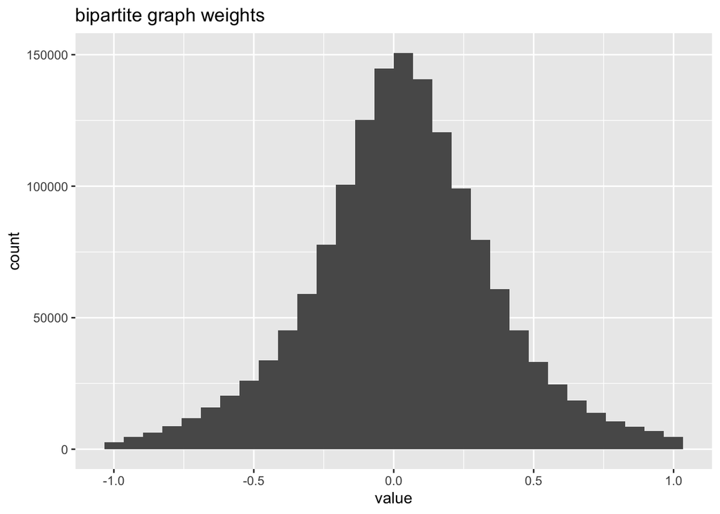

```r
w <- 0.5
a <- 10
b <- 0.4

smoother <- function(x, b, a){
  1/(1 + exp(-a * (abs(x)-b)))
}


de_matrix <- as.matrix(assay(fit, "DE"))
#de_matrix <- de_matrix - mean(de_matrix)
de_matrix <- tanh(w * de_matrix)

data <- data.frame(value = as.vector(de_matrix))
ggplot(data, aes(x=value)) +
  geom_histogram() +
  ggtitle("bipartite graph weights")
```

We’re now in a position to run FABIA. Some care is needed regarding the number of factors $p$ and the sparsity hyperprior $\alpha$. FABIA does not have automated convergence testing or anything, so we need to fiddle our way into finding converged fits…

In a future version, we should restrict the fit to a training set of cells, and use the hold-out cells for testing.

```r
library(fabia)

res <- fabia(
  de_matrix,
  p = 4,
  alpha = 0.5,
  cyc = 500
)
```

The package provides information per cluster, which could give some indication as to the quality of clusters found (somewhat analogous to variance explained for PCA).

[figure not shown]

```r
ic <- res@avini   # information content per factor, length p
plot(sort(ic, decreasing = TRUE), type = "b",
     xlab = "Factor rank", ylab = "Information",
     main = "information content")
```

Let us illustrate one such found bicluster. The `extractBic` function gives membership of cells and genes to biclusters based on threshholding and underlying distributions (neat, check the actual reference for details!). Here, we have Laplace priors and `thresZ = 0.5` and therefore around $25\%$ of cells can be part of a bicluster. FABIA returns in principle two biclusters, the cluster found and its compliment. This makes interpretation a bit convoluted as we see below, since $Y\approx L Z$ is ambigious regarding the absolute sign assignments of loadings and factors. An upregulated bicluster is complemented by a downregulated opposing bicluster and vice versa.

We investigate the cluster in factor 1 to illustrate. We print the gene names found in cluster 1.

```r
biclusters <- extractBic(res, thresZ = .5)


k <- 1      # cluster k = 1
l <- 1      # gene l = 1 in that cluster

# bic and opposite bic...
bic <- biclusters$bic[k,5]$biypn
bicopp <- biclusters$bicopp[k,5]$biynn

#same for genes.
genes <- biclusters$bic[k,3]$bixn
genes_opp <- biclusters$bicopp[k,3]$bixn

print(genes)
```

```
 [1] "ENSG00000179218" "ENSG00000177700" "ENSG00000143947" "ENSG00000198668"
 [5] "ENSG00000226976" "ENSG00000115053" "ENSG00000142871" "ENSG00000105640"
 [9] "ENSG00000172115" "ENSG00000275302" "ENSG00000132475" "ENSG00000149273"
```

We select the first gene, and compare differential expression with the bicluster, the opposite bicluster and also with the traditional LEMUR neighborhood found for this gene.

```r
sel_gene <- genes[l]

ind <- which(neighborhoods$name == sel_gene)
neigh <- unlist(neighborhoods$neighborhood[ind])

p1 <- tibble(umap = umap) |>
  mutate(de = assay(fit, "DE")[sel_gene,]) |>
  arrange(abs(de)) |>
  ggplot(aes(x = umap[,1], y = umap[,2])) +
    geom_point(aes(color = de), size = 0.5) +
    scale_color_gradient2(low = "#FFD800", high= "#0056B9") +
    ggtitle("Differential expression") +
    coord_fixed() + theme_minimal() + theme(plot.margin = margin(0, 0, 0, 0, "pt"))


umap_data <- tibble(
  umap1 = umap[, 1],
  umap2 = umap[, 2],
  cell_id = rownames(umap)
)

# --- Updated p2 (Normal Bicluster) ---
p2 <- umap_data |>
  mutate(
    cat = case_when(
      cell_id %in% intersect(neigh, bic) ~ "In Both",
      cell_id %in% bic                  ~ "In Bic",
      cell_id %in% neigh                ~ "In Neigh",
      TRUE                              ~ "Other"
    ),
    cat = factor(cat, levels = c("In Both", "In Bic", "In Neigh", "Other"))
  ) |>
  arrange(desc(cat)) |> # Draws "Other" first, "Both" last (on top)
  ggplot(aes(x = umap1, y = umap2, color = cat)) +
  geom_point(aes(size = cat == "Other")) +
  scale_color_manual(
    name = "Bicluster Analysis",
    values = c("In Both" = "#e89300", "In Bic" = "#0056B9", "In Neigh" = "#327049", "Other" = "grey85")
  ) +
  scale_size_manual(values = c("TRUE" = 0.4, "FALSE" = 0.6), guide = "none") +
  coord_fixed() + theme_minimal() + theme(plot.margin = margin(0, 0, 0, 0, "pt"))

# --- Updated p3 (Opposite Bicluster) ---
p3 <- umap_data |>
  mutate(
    cat = case_when(
      cell_id %in% intersect(neigh, bicopp) ~ "In Both opp",
      cell_id %in% bicopp                   ~ "In Bicopp",
      cell_id %in% neigh                    ~ "In Neigh",
      TRUE                                  ~ "Other"
    ),
    cat = factor(cat, levels = c("In Both opp", "In Bicopp", "In Neigh", "Other"))
  ) |>
  arrange(desc(cat)) |>
  ggplot(aes(x = umap1, y = umap2, color = cat)) +
  geom_point(aes(size = cat == "Other")) +
  scale_color_manual(
    name = "Opposite Analysis",
    values = c("In Both opp" = "#e89300", "In Bicopp" = "#0056B9", "In Neigh" = "#327049", "Other" = "grey85")
  ) +
  scale_size_manual(values = c("TRUE" = 0.4, "FALSE" = 0.6), guide = "none") +
  coord_fixed() + theme_minimal() + theme(plot.margin = margin(0, 0, 0, 0, "pt"))
```

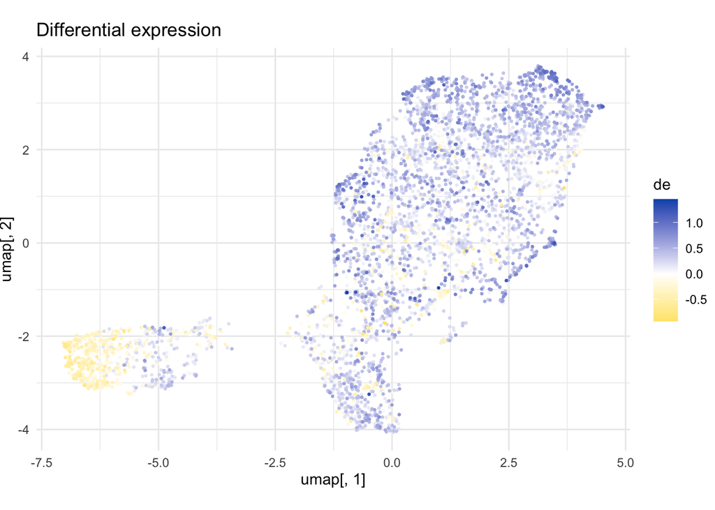

```r
p1
```

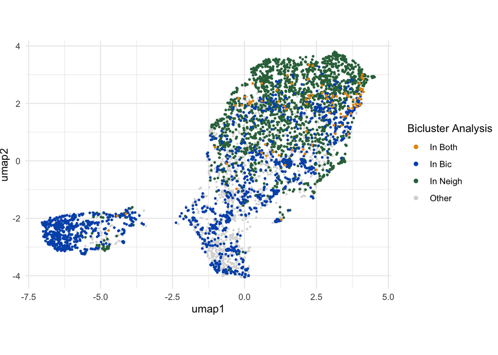

```r
p2
```

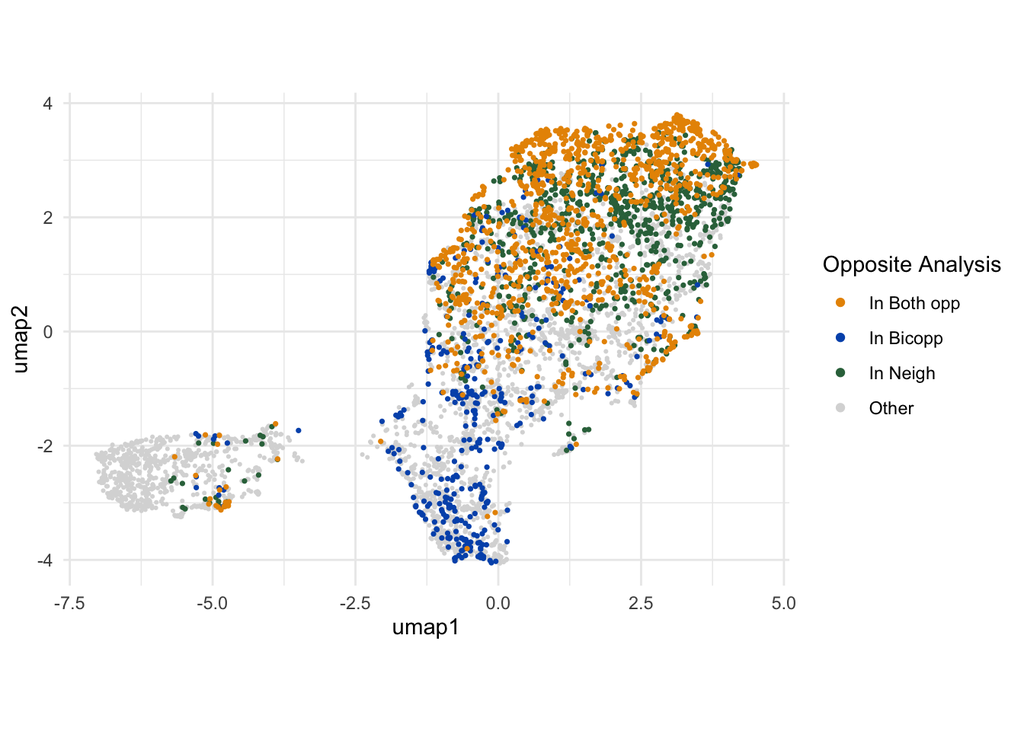

```r
p3 + plot_layout(guides = "collect")
```

Wether the bicluster or the opposite bicluster aligns with the neighborhood can be random and is due to the ambigious sign-assignment between loadings and factors. I need to think of a way to automate that positive loadings correspond to positive differential expression for clear interpretability.

```r
jaccard <- function(A, B){
  num <- length(intersect(A, B))
  denom <- length(union(A, B))
  num/denom
}
```

In this example, we see that the opposite cluster overlaps significantly with the neighborhood from vanilla LEMUR, with Jaccard index 0.4785992. We should note here that

- LEMUR optimised the nieghborhood given the expression for one gene
- bic finds a number of genes that are up- or downregulated in a neighborhood
- therefore, they cannot align fully, however, their overlap is remarkable

```r
figure_wrapper <- function(biclusters, k, neighborhoods){

  bic <- biclusters$bic[k,5]$biypn
  bicopp <- biclusters$bicopp[k,5]$biynn
  genes <- biclusters$bic[k,3]$bixn
  genes_opp <- biclusters$bicopp[k,3]$bixn

  for (l in 1:length(genes)) {

    sel_gene <- genes[l]

    p<- tibble(umap = umap) |>
      mutate(de = assay(fit, "DE")[sel_gene,]) |>
      #arrange(abs(de)) |>
      ggplot(aes(x = umap[,1], y = umap[,2])) +
        geom_point(aes(color = de), size = 0.5) +
        coord_fixed() +
        scale_color_gradient2(low = "#FFD800", high= "#0056B9")

    ind <- which(neighborhoods$name == sel_gene)
    neigh <- unlist(neighborhoods$neighborhood[ind])

    pp <- tibble(
      umap1     = umap[, 1],
      umap2     = umap[, 2],
      # Cleaned up the indicator logic
      indicator_old = ifelse(rownames(umap) %in% neigh, "In Neigh", "Other"),
      indicator_new = ifelse(rownames(umap) %in% bic, "In Bic", "Other"),
      indicator_opp = ifelse(rownames(umap) %in% bicopp, "In Bicopp", "Other"),
      indicator_int = ifelse(rownames(umap) %in% intersect(neigh, bic), "In Both", "Other"),
      indicator_intopp = ifelse(rownames(umap) %in% intersect(neigh, bicopp), "In Both opp", "Other")
    ) |>
      ggplot(aes(x = umap1, y = umap2)) +
        # Use an anonymous function \(d) to tell subset() to use the piped tibble
        geom_point(
          data = \(d) subset(d, indicator_old == "Other"),
          color = "grey85",
          size = 0.4
        ) +
        geom_point(
          data = \(d) subset(d, indicator_old == "In Neigh"),
          color = "#327049",
          size = 0.6
        ) +
        geom_point(
          data = \(d) subset(d, indicator_new == "In Bic"),
          color = "#0056B9",
          size = 0.6
        ) +
        geom_point(
          data = \(d) subset(d, indicator_int == "In Both"),
          color = "#e89300",
          size = 0.6
        ) +
        coord_fixed() +
        theme_minimal()

    ppp <- tibble(
      umap1     = umap[, 1],
      umap2     = umap[, 2],
      # Cleaned up the indicator logic
      indicator_old = ifelse(rownames(umap) %in% neigh, "In Neigh", "Other"),
      indicator_new = ifelse(rownames(umap) %in% bic, "In Bic", "Other"),
      indicator_opp = ifelse(rownames(umap) %in% bicopp, "In Bicopp", "Other"),
      indicator_int = ifelse(rownames(umap) %in% intersect(neigh, bic), "In Both", "Other"),
      indicator_intopp = ifelse(rownames(umap) %in% intersect(neigh, bicopp), "In Both opp", "Other")
    ) |>
      ggplot(aes(x = umap1, y = umap2)) +
        # Use an anonymous function \(d) to tell subset() to use the piped tibble
        geom_point(
          data = \(d) subset(d, indicator_old == "Other"),
          color = "grey85",
          size = 0.4
        ) +
        geom_point(
          data = \(d) subset(d, indicator_old == "In Neigh"),
          color = "#327049",
          size = 0.6
        ) +

        geom_point(
          data = \(d) subset(d, indicator_opp == "In Bicopp"),
          color = "#0056B9",
          size = 0.6
        ) +
        geom_point(
          data = \(d) subset(d, indicator_intopp == "In Both opp"),
          color = "#e89300",
          size = 0.6
        ) +

        coord_fixed() +
        theme_minimal()

        print(p)
        print(
            pp + ppp +
            theme(
                plot.margin = margin(2, 2, 2, 2, "pt"),
                legend.box.margin = margin(0, 0, 0, 0, "pt")
            )
        )
  }
}
```

Repeating a similar exercise for all genes we assigned to bicluster 1:

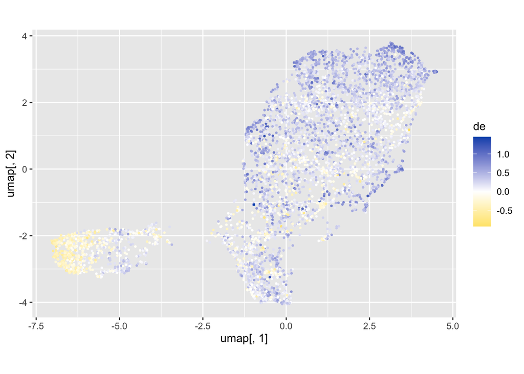

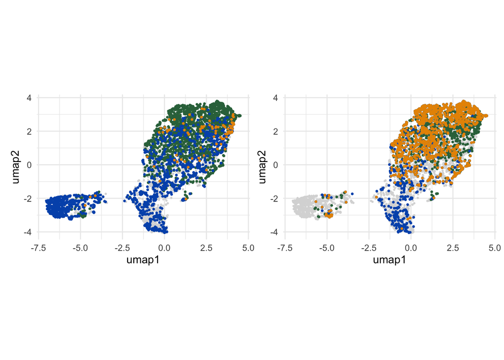

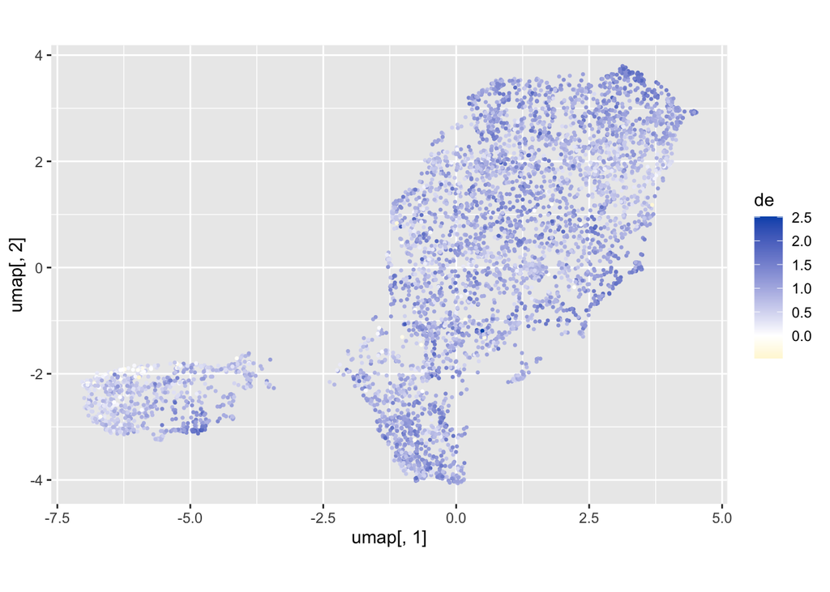

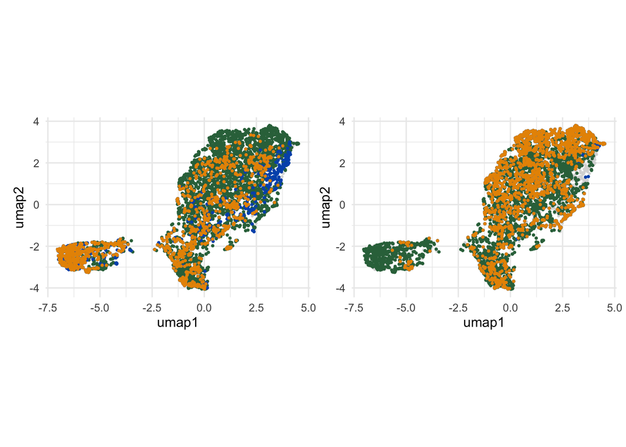

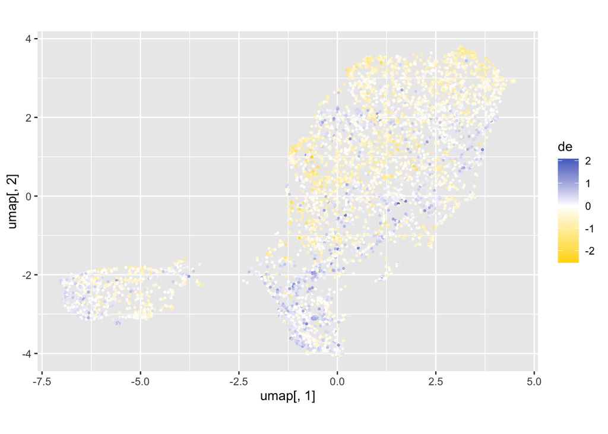

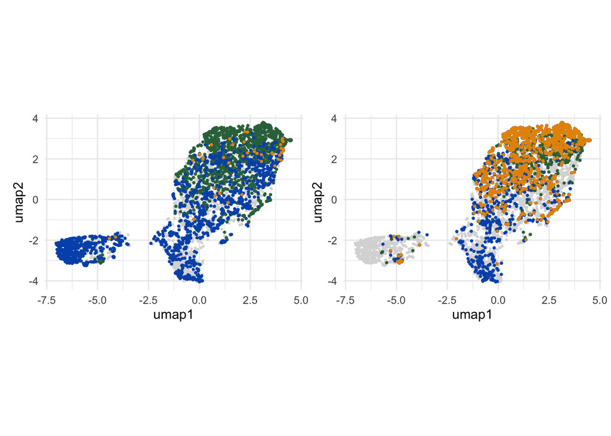

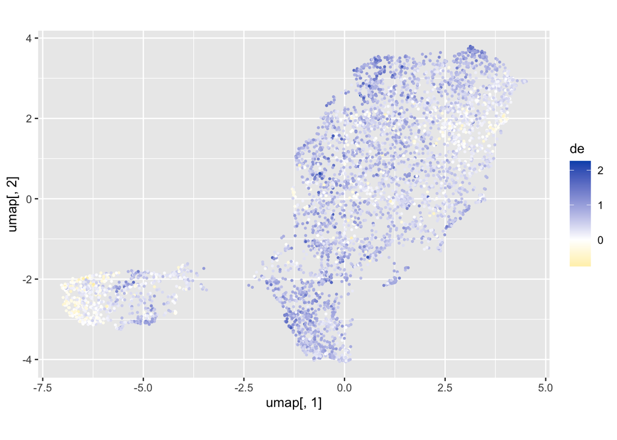

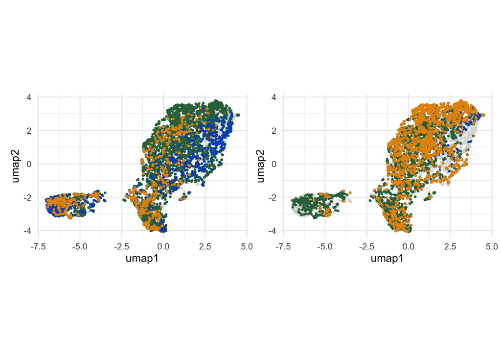

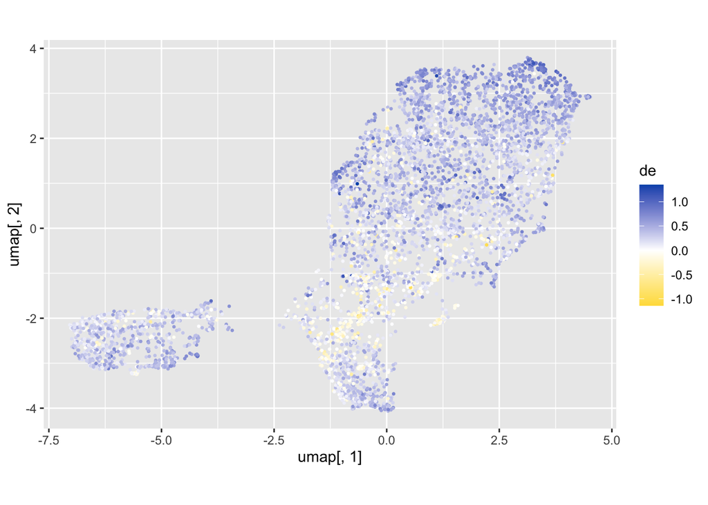

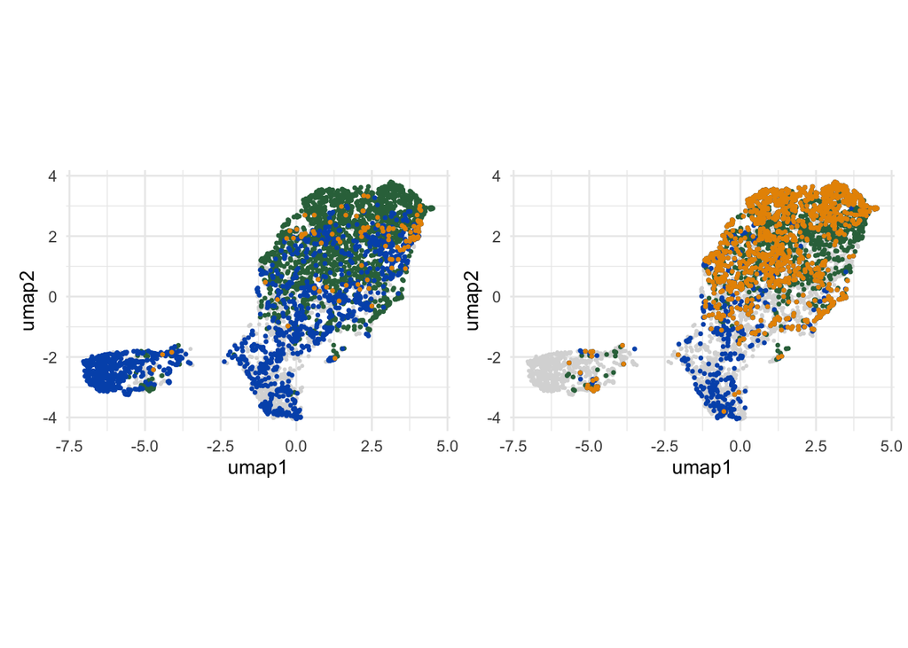

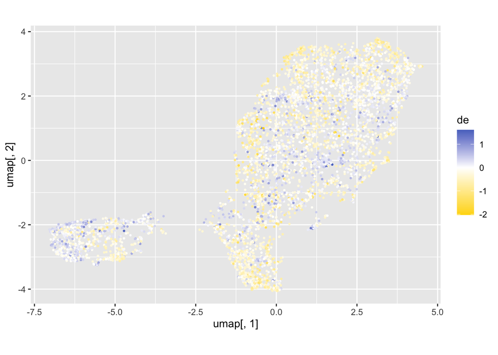

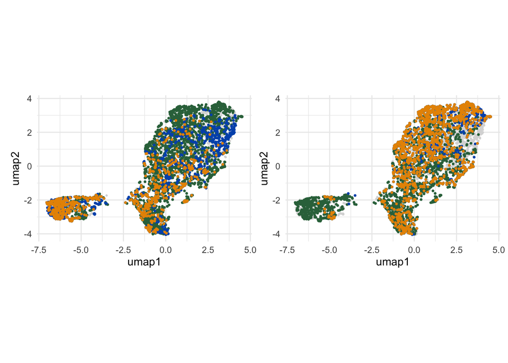

[12 more figures not shown]

```r
figure_wrapper(biclusters, 1, neighborhoods)
```